# Logistic Regression

# Section 1: Simple Logistic Regression

## Loading Dataset and Libraries

```r
library(tidyverse)
library(Statamarkdown)
# pprint has been updated
# devtools::install_github("Kss2k/pprint")
library(pprint)
# New Packages
  # new_packages <- c("DescTools", "visreg", "lmtest")
  # install.packages(new_packages)
library(visreg)
library(lmtest)
library(DescTools)
```

**R**

```r
setwd("C:/Users/slupp/OneDrive/Skrivebord/NTNU/Mehmet/PSY8003/Logistic_regression")
titanic <- readRDS("titanic.rds")
psummary(titanic)
```

```
# Color data frame (class colorDF) 9 x 13:
│Variables  │Type     │Obs  │Missing│Unique│Mean   │SD     │Min  │Max
│PassengerId│  integer│ 1309│      0│  1309│655.000│378.020│ 1.00│ 1309
│Survived   │  integer│  891│    418│     3│  0.384│  0.487│ 0.00│    1
│Pclass     │  integer│ 1309│      0│     3│  2.295│  0.838│ 1.00│    3
│Name       │character│ 1309│      0│  1307│     NA│     NA│   NA│   NA
│Sex        │character│ 1309│      0│     2│     NA│     NA│   NA│   NA
│Age        │  numeric│ 1046│    263│    99│ 29.881│ 14.413│ 0.17│   80
│SibSp      │  integer│ 1309│      0│     7│  0.499│  1.042│ 0.00│    8
│Parch      │  integer│ 1309│      0│     8│  0.385│  0.866│ 0.00│    9
│Ticket     │character│ 1309│      0│   929│     NA│     NA│   NA│   NA
│Fare       │  numeric│ 1308│      1│   282│ 33.295│ 51.759│ 0.00│  512
│Cabin      │character│ 1309│      0│   187│     NA│     NA│   NA│   NA
│Embarked   │character│ 1309│      0│     4│     NA│     NA│   NA│   NA
│Age2       │  numeric│  891│    418│    34│ 19.713│  6.836│ 4.00│   38
```

**STATA**

```
> n"
C:\Users\slupp\OneDrive\Skrivebord\NTNU\Mehmet\PSY8003\Logistic_regression
```

## Quick Recap

1. Logistic Regression is used when we have categorical dependent variables
2. Here we can no longer use a normal regression; since it is not bound between (0,1) and it should not be linear; rather sigmoidal (representing probability).
3. We transform the lefthand side of the equation to the log of the odds.
4. The log(odds) (i.e., logit) scales linearly, so it can be expressed in terms of our general(ized) linear equation.
5. Common misconceptions:
   1. We do not transform our dependent variable to log-odds
   2. We do not transform our independent variable to log-odds
   3. We do not change the general linear equation (B0 + B1X1 + BkXk)
   4. Rather we change the left hand side, so that we no longer predict our observed variable, but rather a probability of our observed variable.
   5. This makes it so we no longer can use OLS, but instead maximum likelyhood
6. Logisitc regression is most often used with dichotomous variables, but can also be used with categorical variables with more than two categories

## Example 1: Simple Logistic Regression

1. Lets say we want to assess whether age predicts survival at the titanic
2. Put dependent variable is Survived (0 = died, 1 = survived)
3. Our independent variable is age:
4. For this we have to use the glm function in R
   1. GLM stands for generalized linear model, which allows for the use of different distributions of our Y-variable, than just the normal-distribution
5. In STATA we use the *logit* command, which basically has the same syntax as the regress command

**R**

Here we look at the effect of Age (NB i created a variable for this example (Age2) which has a very strong effect, so as to make the non-linearity more obvious). on Survival

```r
psummary(reg_survived_age)
```

```
 Model fit: Survived
# Color data frame (class colorDF) 1 x 5:
                  │Values
Number of Obs   = │ 891.000
Log Likelyhood  = │ -66.388
Chi Square      = │1053.880
Prob > ChiSq    = │   0.000
Pseudo R2       = │   0.888


 Coefficients: Survived
# Color data frame (class colorDF) 6 x 2:
           │Coefficients│std.error│t-value│p-value│CI[2.5%]│CI[97.5%]
(Intercept)│      -24.77│     2.47│ -10.03│ <2e-16│ -30.202│   -20.44
       Age2│        1.19│     0.12│   9.88│ <2e-16│   0.976│     1.45
```

**R: Significance Test**

```r
# library(lmtest)
lrtest(reg_survived_age)
```

```
Likelihood ratio test

Model 1: Survived ~ Age2
Model 2: Survived ~ 1
  #Df  LogLik Df  Chisq Pr(>Chisq)
1   2  -66.39
2   1 -593.33 -1 1053.9  < 2.2e-16 ***
---
Signif. codes:  0 ‘***’ 0.001 ‘**’ 0.01 ‘*’ 0.05 ‘.’ 0.1 ‘ ’ 1
```

**R: Goodness of fit**

```r
#library(DescTools)
PseudoR2(reg_survived_age, which = "McFadden" # Sane as in STATA and pprint
         )
```

```
 McFadden
0.8881096
```

**pprint**

Or you could just use the pprint function psummary()

```r
psummary(reg_survived_age, odds_ratio = T)
```

```
 Model fit: Survived
# Color data frame (class colorDF) 1 x 5:
                  │Values
Number of Obs   = │ 891.000
Log Likelyhood  = │ -66.388
Chi Square      = │1053.880
Prob > ChiSq    = │   0.000
Pseudo R2       = │   0.888


 Coefficients: Survived
# Color data frame (class colorDF) 7 x 2:
           │Coefficients│OddsRatio│std.error│t-value│p-value│CI[2.5%]│CI[97.5%]
(Intercept)│      -24.77│     0.00│     2.47│ -10.03│ <2e-16│ -30.202│   -20.44
       Age2│        1.19│     3.27│     0.12│   9.88│ <2e-16│   0.976│     1.45
```

**STATA**

```
Iteration 0:   log likelihood = -593.32757
Iteration 1:   log likelihood = -75.106944
Iteration 2:   log likelihood = -68.020832
Iteration 3:   log likelihood = -66.392294
Iteration 4:   log likelihood = -66.387668
Iteration 5:   log likelihood = -66.387668

Logistic regression                             Number of obs     =        891
                                                LR chi2(1)        =    1053.88
                                                Prob > chi2       =     0.0000
Log likelihood = -66.387668                     Pseudo R2         =     0.8881

------------------------------------------------------------------------------
    Survived |      Coef.   Std. Err.      z    P>|z|     [95% Conf. Interval]
-------------+----------------------------------------------------------------
        Age2 |   1.186496   .1201545     9.87   0.000     .9509979    1.421995
       _cons |  -24.77392       2.47   -10.03   0.000    -29.61503    -19.9328
------------------------------------------------------------------------------
Note: 1 failure and 4 successes completely determined.
```

**Someone who wants to interpret?**

```r
cat(interpretation_1)
```

```
1. Firstly we can see that the model as a whole is significant and has a large Pseudo R2

2. Secondly we can see that the intercept is -24, indicating an estimated log(odds) (logit) of -24 at age = 0.

3. Thirdly we can see that the coefficient for age2 is 1.18 (p <.001) indicating a 1.18 increas in logit (increasing odds for surviving) per one unit change (1 year) in age.
```

### Converting to Probabilities

1. In general it is difficult to interpret logits, and we usually want to use different (more intuitive) measures.
2. One measure is probabilites
3. Change i probability depends on where you are on the x-axis (i.e., the change is not linear), so we need to specify what points to compare

```r
plogis(coefficents_model) |> format(scientific = F)
```

```
          (Intercept)                  Age2
"0.00000000001741105" "0.76611388032992311"
```

1. This is a bit tricky to interpret, but the intercept represents the probability of surviving for a newborn.
2. While Age2 represents the probability of surviving for a one-year old; IF the probability of survival was .5 for a newborn.
3. This is not very useful, so we could instead use the mean as the reference.
4. Here we just use the logit coefficients and predict logitvalues for age 10 and 20
5. Then we compute the difference in logit, and use the plogis function to compute the difference between the two

```r
prob_10 <- plogis(coefficents_model[ "(Intercept)"] + 10*coefficents_model["Age2"])

prob_20 <- plogis(coefficents_model[ "(Intercept)"] + 20*coefficents_model["Age2"])

prob_10 |> round(3)
```

```
(Intercept)
          0
```

```r
prob_20 |> round(3)
```

```
(Intercept)
       0.26
```

```r
(prob_20 - prob_10) |> round(3)
```

```
(Intercept)
       0.26
```

```r
prob_20 <- plogis(coefficents_model[ "(Intercept)"] + 20*coefficents_model["Age2"])

prob_30 <- plogis(coefficents_model[ "(Intercept)"] + 30*coefficents_model["Age2"])

prob_20 |> round(3)
```

```
(Intercept)
       0.26
```

```r
prob_30 |> round(3)
```

```
(Intercept)
          1
```

```r
(prob_30 - prob_20) |> round(3)
```

```
(Intercept)
       0.74
```

1. Here we can see that we go from 26% to almost 100% likelihood of survival; a larger change (74%)
2. A more direct way can be done using the predict function
3. Remember that this is an artificial variable created for demonstrative purposes

```r
values_to_predict <- data.frame(Age2 = 1:40)


predict(reg_survived_age, newdata =values_to_predict) |> plogis() |> round(5)
```

```
      1       2       3       4       5       6       7       8       9      10
0.00000 0.00000 0.00000 0.00000 0.00000 0.00000 0.00000 0.00000 0.00000 0.00000
     11      12      13      14      15      16      17      18      19      20
0.00001 0.00003 0.00009 0.00028 0.00093 0.00305 0.00992 0.03177 0.09705 0.26038
     21      22      23      24      25      26      27      28      29      30
0.53557 0.79068 0.92522 0.97592 0.99252 0.99771 0.99930 0.99979 0.99993 0.99998
     31      32      33      34      35      36      37      38      39      40
0.99999 1.00000 1.00000 1.00000 1.00000 1.00000 1.00000 1.00000 1.00000 1.00000
```

we can do the same in STATA using the margins command

```
Adjusted predictions                            Number of obs     =        891
Model VCE    : OIM

Expression   : Pr(Survived), predict()

1._at        : Age2            =           0

2._at        : Age2            =           5

3._at        : Age2            =          10

4._at        : Age2            =          15

5._at        : Age2            =          20

6._at        : Age2            =          25

7._at        : Age2            =          30

8._at        : Age2            =          35

9._at        : Age2            =          40

------------------------------------------------------------------------------
             |            Delta-method
             |     Margin   Std. Err.      z    P>|z|     [95% Conf. Interval]
-------------+----------------------------------------------------------------
         _at |
          1  |   1.74e-11   4.30e-11     0.40   0.686    -6.69e-11    1.02e-10
          2  |   6.57e-09   1.23e-08     0.53   0.593    -1.75e-08    3.07e-08
          3  |   2.48e-06   3.17e-06     0.78   0.434    -3.73e-06    8.68e-06
          4  |   .0009327   .0006493     1.44   0.151      -.00034    .0022054
          5  |   .2603816   .0461784     5.64   0.000     .1698735    .3508896
          6  |   .9925236   .0043981   225.67   0.000     .9839035    1.001144
          7  |     .99998   .0000234  4.3e+04   0.000     .9999343    1.000026
          8  |   .9999999   9.33e-08  1.1e+07   0.000     .9999998           1
          9  |          1   3.31e-10  3.0e+09   0.000            1           1
------------------------------------------------------------------------------
```

We can use these predictions, to visualize our model.

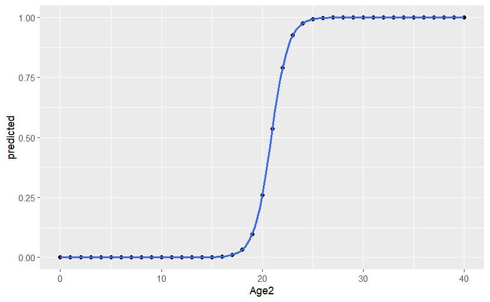

```r
values_to_predict <- data.frame(Age2 = c(seq(0,
                                             40,
                                             1)
                                         )
                                )

values_to_predict = mutate(values_to_predict, predicted = predict(reg_survived_age, newdata =values_to_predict) |> plogis() |> round(5))

values_to_predict %>% ggplot(aes(x = Age2,
                                 y = predicted)) +
  geom_point() +
  geom_smooth(method = "glm", method.args = list(family = binomial), se = F )
```

```r
NA
```

Here the points represent our predicted values for x = 1, 2 … 40

**Using the actual datapoints:**

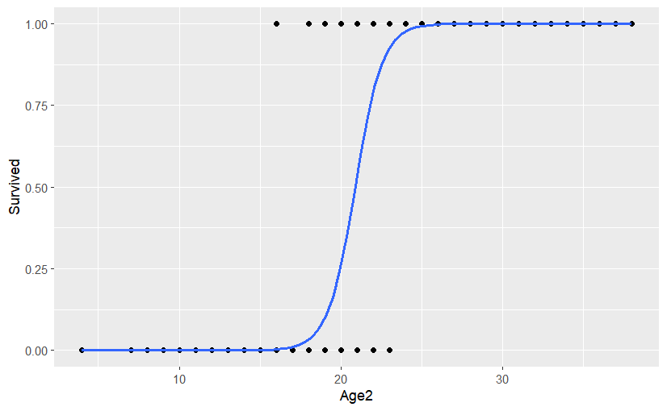

```r
titanic %>% ggplot(aes(Age2, Survived)) +
  geom_point() +
  geom_smooth(method = "glm", formula = y ~x, method.args = list(family = binomial), se = F)
```

```r
NA
```

**Simple Version:**

We can also visualize our model using the visreg package, which is a bit simpler.

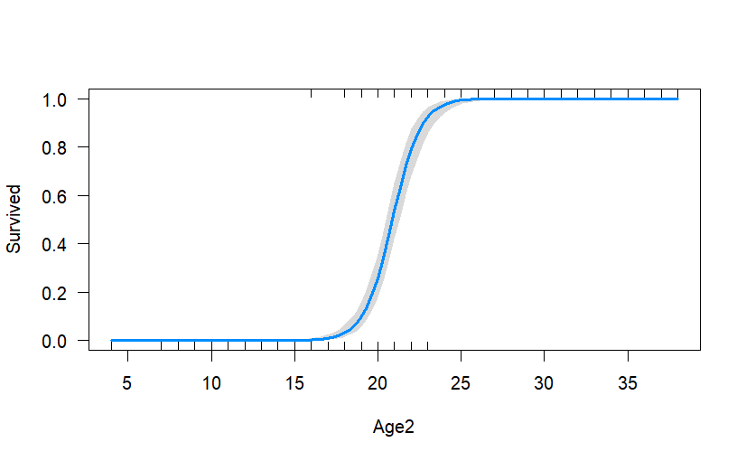

```stata
quietly logit Survived Age2
margins , at(Age2 = (0(0.2)40))

//Without CI (noci) and points (msize)
marginsplot, noci plotopts(msize(0) lwidth(0.6))
```

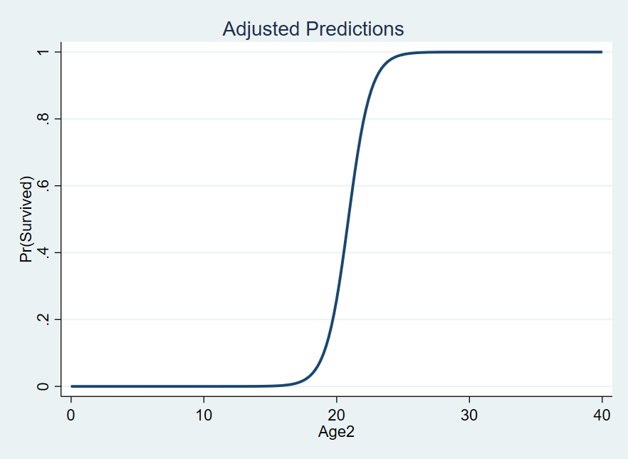

### Change in oddsratio

Instead of expressing changes in probability, we can also express them as changes in odds ratios. OR can be interpreted similarily to logodds, where they represent the relative change (not absolute) in OR per unit increase in X

To find OR in R we can simply use the exp()

```r
exp(coefficents_model)
```

```
 (Intercept)         Age2
1.741105e-11 3.275585e+00
```

This means that for each one step increase in X, the OR increases by 3.28 times the previous step.

We can also use psummary()

```r
psummary(reg_survived_age, odds_ratio = TRUE)
```

```
 Model fit: Survived
# Color data frame (class colorDF) 1 x 5:
                  │Values
Number of Obs   = │ 891.000
Log Likelyhood  = │ -66.388
Chi Square      = │1053.880
Prob > ChiSq    = │   0.000
Pseudo R2       = │   0.888


 Coefficients: Survived
# Color data frame (class colorDF) 7 x 2:
           │Coefficients│OddsRatio│std.error│t-value│p-value│CI[2.5%]│CI[97.5%]
(Intercept)│      -24.77│     0.00│     2.47│ -10.03│ <2e-16│ -30.202│   -20.44
       Age2│        1.19│     3.27│     0.12│   9.88│ <2e-16│   0.976│     1.45
```

**STATA**

In STATA we can simply use the logistic function, instead of logit.

```
Logistic regression                             Number of obs     =        891
                                                LR chi2(1)        =    1053.88
                                                Prob > chi2       =     0.0000
Log likelihood = -66.387668                     Pseudo R2         =     0.8881

------------------------------------------------------------------------------
    Survived | Odds Ratio   Std. Err.      z    P>|z|     [95% Conf. Interval]
-------------+----------------------------------------------------------------
        Age2 |   3.275585   .3935764     9.87   0.000     2.588291    4.145382
       _cons |   1.74e-11   4.30e-11   -10.03   0.000     1.38e-13    2.20e-09
------------------------------------------------------------------------------
Note: _cons estimates baseline odds.
Note: 1 failure and 4 successes completely determined.
```

1. As with probability we can predict different OR at different ages
2. But, if you bother to do this, you might as well use probabilities, as they are more intuitive to interpret

```r
OR_10 <- exp(coefficents_model[ "(Intercept)"] + 10*coefficents_model["Age2"])

OR_20 <- exp(coefficents_model[ "(Intercept)"] + 20*coefficents_model["Age2"])

OR_10
```

```
 (Intercept)
2.475789e-06
```

```r
OR_20
```

```
(Intercept)
  0.3520485
```

```r
OR_20 - OR_10
```

```
(Intercept)
  0.3520461
```

```r
OR_20 <- exp(coefficents_model[ "(Intercept)"] + 20*coefficents_model["Age2"])

OR_30 <- exp(coefficents_model[ "(Intercept)"] + 30*coefficents_model["Age2"])


OR_30 - OR_20
```

```
(Intercept)
   50059.71
```

1. In general this is a bit tricky to interpret, since the change in OR increases exponentially per unit increase in X.
2. Although we can see that we get the same probability plot by using our ODDS-ratio coefficients, instead of Log(odds) coefficients, we can also that the absolute change in OR increases exponentially

**Calculating probability using OR-coefficients (just to demonstrate)**

```r
# Function for calculating odds ratio for level in X
odds_ratio_function <- function(x) {
  initial_odds <- exp(coefficents_model[ "(Intercept)"])
  coeff <- exp(coefficents_model["Age2"])
  initial_odds*coeff^x
}

# Function for calculating probability based on odds
odds_to_probability <- function(x) {
  odds_ratio <- odds_ratio_function(x)
  odds_ratio/(odds_ratio + 1)
}
```

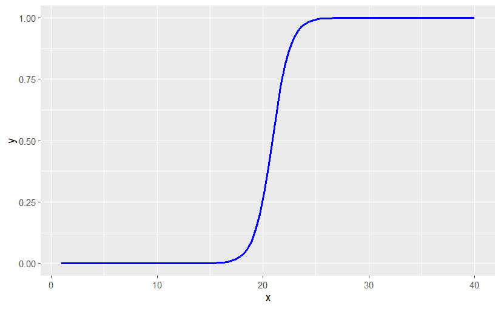

```r
plot_prob <- data.frame(x = 1:40,
                      y = odds_to_probability(1:40))

ggplot(plot_prob, aes(x, y)) +
  geom_function(fun = odds_to_probability,
                color = "blue",
                linewidth = 1
  )
```

```r
NA
```

1. Here we can see that we get the exact same curve using the oddsratio, as we did using the logit
2. I.e., this shows us the relative change in probability
3. The relative change in odds is 3.2755 times the change in X, which corresponds to an exponential increase in absolute change:

**Absolute change in OR (just to demonstrate)**

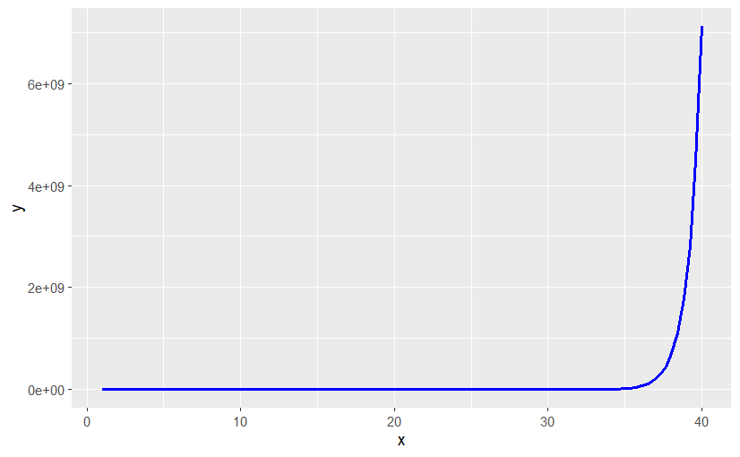

```r
plot_abs <- data.frame(x = 1:40,
                       y = odds_ratio_function(1:40))

ggplot(plot_abs, aes(x,y)) +
  geom_function(fun = odds_ratio_function,
                color = "blue",
                linewidth = 1)
```

### Prediction Accuracy: Sensitivity and Specificity

1. Another measure of goodness of fit is how well our model predicts; or rather how well it classifies our datapoints.
2. Sensitivity is the proportion of true positives
3. Specificity is the proportion of true negatives

**R**

```r
# Gathering the dataset used in our model (this way we do not need to remove missing values our selves)
model_data_with_predictions <- reg_survived_age[["model"]] |>
  mutate(predicted_logit = predict(reg_survived_age))

# Converting fitted logit to probabilites
model_data_with_predictions <- model_data_with_predictions %>% mutate(
  predicted = 1/(1 + exp(-predicted_logit))
)

# Using the case_when function to predict which category someone belongs to
model_data_with_predictions <- model_data_with_predictions %>% mutate(
  predicted = case_when(predicted <= 0.5 ~ 0,
                        predicted >= 0.5 ~ 1)
)

# Optionally we can just use the logit it selv, since 0.5 corresponds to 0 logit
model_data_with_predictions <- model_data_with_predictions %>% mutate(
  predicted2 = case_when(predicted_logit <= 0 ~ 0,
                        predicted_logit >= 0 ~ 1)
)

# Using probability
table(model_data_with_predictions$Survived,
      model_data_with_predictions$predicted)
```

```
      0   1
  0 537  12
  1  11 331
```

```r
# Using logit
table(model_data_with_predictions[,1],
      model_data_with_predictions[,4])
```

```
      0   1
  0 537  12
  1  11 331
```

From these numbers we can calculate our sensitivity, specificity, positive predictive value etc. Doing it this way is a bit tedious, and it is easier to use a pre-programmed function (e.g., pprint)

```r
psummary(reg_survived_age, accuracy = T)
```

```
 Model fit: Survived
# Color data frame (class colorDF) 1 x 5:
                  │Values
Number of Obs   = │ 891.000
Log Likelyhood  = │ -66.388
Chi Square      = │1053.880
Prob > ChiSq    = │   0.000
Pseudo R2       = │   0.888


 Coefficients: Survived
# Color data frame (class colorDF) 6 x 2:
           │Coefficients│std.error│t-value│p-value│CI[2.5%]│CI[97.5%]
(Intercept)│      -24.77│     2.47│ -10.03│ <2e-16│ -30.202│   -20.44
       Age2│        1.19│     0.12│   9.88│ <2e-16│   0.976│     1.45


 Predicted and Observed Positives and Negatives
# Color data frame (class colorDF) 3 x 3:
                 │Predicted Negative│Predicted Positive│Total
Observed Negative│               537│                11│  548
Observed Positive│                12│               331│  343
            Total│               549│               342│  891


 Sensitivity and Specificity
# Color data frame (class colorDF) 1 x 4:
                         │Percentage
              Sensitivity│     0.968
              Specificity│     0.978
 Positve Predictive Value│     0.965
Negative Predictive Value│     0.980
```

**STATA**

In STATA we can simply type *estat* (i.e., estimate statistic) *class* (i.e., classification)

```
Iteration 0:   log likelihood = -593.32757
Iteration 1:   log likelihood = -75.106944
Iteration 2:   log likelihood = -68.020832
Iteration 3:   log likelihood = -66.392294
Iteration 4:   log likelihood = -66.387668
Iteration 5:   log likelihood = -66.387668

Logistic regression                             Number of obs     =        891
                                                LR chi2(1)        =    1053.88
                                                Prob > chi2       =     0.0000
Log likelihood = -66.387668                     Pseudo R2         =     0.8881

------------------------------------------------------------------------------
    Survived |      Coef.   Std. Err.      z    P>|z|     [95% Conf. Interval]
-------------+----------------------------------------------------------------
        Age2 |   1.186496   .1201545     9.87   0.000     .9509979    1.421995
       _cons |  -24.77392       2.47   -10.03   0.000    -29.61503    -19.9328
------------------------------------------------------------------------------
Note: 1 failure and 4 successes completely determined.


Logistic model for Survived

              -------- True --------
Classified |         D            ~D  |      Total
-----------+--------------------------+-----------
     +     |       331            12  |        343
     -     |        11           537  |        548
-----------+--------------------------+-----------
   Total   |       342           549  |        891

Classified + if predicted Pr(D) >= .5
True D defined as Survived != 0
--------------------------------------------------
Sensitivity                     Pr( +| D)   96.78%
Specificity                     Pr( -|~D)   97.81%
Positive predictive value       Pr( D| +)   96.50%
Negative predictive value       Pr(~D| -)   97.99%
--------------------------------------------------
False + rate for true ~D        Pr( +|~D)    2.19%
False - rate for true D         Pr( -| D)    3.22%
False + rate for classified +   Pr(~D| +)    3.50%
False - rate for classified -   Pr( D| -)    2.01%
--------------------------------------------------
Correctly classified                        97.42%
--------------------------------------------------
```

## Exercises

1. Run a logistic regression where Survived is the dependent variable, and independent is Age (NOT Age2!)
2. Interpret the regression
3. Use the regression to predict the probability of surviving at ages 0, 10, 20, 30 and 40.
4. Find the sensitivity and specificity of your model
5. Visualize your regression on a 2d plot

# Section 2: Multiple Logistic Regression

In this section we’re going to look at more complex logistic regression models, using dummy variables and interaction terms

## Example 1: Adding a dummy-variable

1. In this example were going to predict *Survived* using *Sex* and Age

**R**

```r
psummary(reg_survived_sex_age, accuracy = T)
```

```
 Model fit: Survived
# Color data frame (class colorDF) 1 x 5:
                  │Values
Number of Obs   = │ 714.000
Log Likelyhood  = │-374.978
Chi Square      = │ 214.559
Prob > ChiSq    = │   0.000
Pseudo R2       = │   0.222


 Coefficients: Survived
# Color data frame (class colorDF) 6 x 3:
           │Coefficients│std.error│t-value│p-value │CI[2.5%]│CI[97.5%]
(Intercept)│       1.277│    0.230│   5.55│2.87e-08│   0.835│    1.738
    Sexmale│      -2.466│    0.185│ -13.30│ < 2e-16│  -2.836│   -2.108
        Age│      -0.005│    0.006│  -0.86│    0.39│  -0.018│    0.007


 Predicted and Observed Positives and Negatives
# Color data frame (class colorDF) 3 x 3:
                 │Predicted Negative│Predicted Positive│Total
Observed Negative│               360│                93│  453
Observed Positive│                64│               197│  261
            Total│               424│               290│  714


 Sensitivity and Specificity
# Color data frame (class colorDF) 1 x 4:
                         │Percentage
              Sensitivity│     0.679
              Specificity│     0.849
 Positve Predictive Value│     0.755
Negative Predictive Value│     0.795
```

**STATA**

```
Iteration 0:   log likelihood = -482.25798
Iteration 1:   log likelihood = -375.39416
Iteration 2:   log likelihood = -374.97888
Iteration 3:   log likelihood = -374.97847
Iteration 4:   log likelihood = -374.97847

Logistic regression                             Number of obs     =        714
                                                LR chi2(2)        =     214.56
                                                Prob > chi2       =     0.0000
Log likelihood = -374.97847                     Pseudo R2         =     0.2225

------------------------------------------------------------------------------
    Survived |      Coef.   Std. Err.      z    P>|z|     [95% Conf. Interval]
-------------+----------------------------------------------------------------
         Sex |   -2.46592   .1853836   -13.30   0.000    -2.829265   -2.102575
         Age |  -.0054259   .0063099    -0.86   0.390    -.0177931    .0069413
       _cons |   1.277273   .2301689     5.55   0.000     .8261504    1.728396
------------------------------------------------------------------------------


Logistic model for Survived

              -------- True --------
Classified |         D            ~D  |      Total
-----------+--------------------------+-----------
     +     |       197            64  |        261
     -     |        93           360  |        453
-----------+--------------------------+-----------
   Total   |       290           424  |        714

Classified + if predicted Pr(D) >= .5
True D defined as Survived != 0
--------------------------------------------------
Sensitivity                     Pr( +| D)   67.93%
Specificity                     Pr( -|~D)   84.91%
Positive predictive value       Pr( D| +)   75.48%
Negative predictive value       Pr(~D| -)   79.47%
--------------------------------------------------
False + rate for true ~D        Pr( +|~D)   15.09%
False - rate for true D         Pr( -| D)   32.07%
False + rate for classified +   Pr(~D| +)   24.52%
False - rate for classified -   Pr( D| -)   20.53%
--------------------------------------------------
Correctly classified                        78.01%
--------------------------------------------------
```

**Anyone want to interpret?**

```r
cat(interpretation_2)
```

[output not shown]

1. To get a better sense of our model we can check the difference in porbability between men and women (i.e. the effect of sex), at mean Age

```r
coefficents_model <- coefficients(reg_survived_sex_age)

mean_age <- mean(titanic$Age, na.rm = T)

prob_mean_age_female <- plogis(coefficents_model["(Intercept)"] +
                                 mean_age*coefficents_model["Age"]
                                 )

prob_mean_age_male <- plogis(coefficents_model["(Intercept)"] +
                               mean_age*coefficents_model["Age"] +
                               coefficents_model["Sexmale"])
prob_mean_age_female
```

```
(Intercept)
  0.7530863
```

```r
prob_mean_age_male
```

```
(Intercept)
   0.205743
```

```r
prob_mean_age_male - prob_mean_age_female
```

```
(Intercept)
 -0.5473433
```

**STATA**

```
Iteration 0:   log likelihood = -482.25798
Iteration 1:   log likelihood = -375.39416
Iteration 2:   log likelihood = -374.97888
Iteration 3:   log likelihood = -374.97847
Iteration 4:   log likelihood = -374.97847

Logistic regression                             Number of obs     =        714
                                                LR chi2(2)        =     214.56
                                                Prob > chi2       =     0.0000
Log likelihood = -374.97847                     Pseudo R2         =     0.2225

------------------------------------------------------------------------------
    Survived |      Coef.   Std. Err.      z    P>|z|     [95% Conf. Interval]
-------------+----------------------------------------------------------------
         Sex |   -2.46592   .1853836   -13.30   0.000    -2.829265   -2.102575
         Age |  -.0054259   .0063099    -0.86   0.390    -.0177931    .0069413
       _cons |   1.277273   .2301689     5.55   0.000     .8261504    1.728396
------------------------------------------------------------------------------


Adjusted predictions                            Number of obs     =        714
Model VCE    : OIM

Expression   : Pr(Survived), predict()

1._at        : Sex             =           0
               Age             =    29.69912 (mean)

2._at        : Sex             =           1
               Age             =    29.69912 (mean)

------------------------------------------------------------------------------
             |            Delta-method
             |     Margin   Std. Err.      z    P>|z|     [95% Conf. Interval]
-------------+----------------------------------------------------------------
         _at |
          1  |   .7532699   .0267944    28.11   0.000     .7007539    .8057859
          2  |   .2059045   .0190322    10.82   0.000     .1686021    .2432069
------------------------------------------------------------------------------
```

Here we can see that men at mean age have a 54% lower probability of surviving compared to women. More specifically women at mean age have a 75% probability of surviving, while men have a 21% probability of surviving

### Visualizing adding a dummy

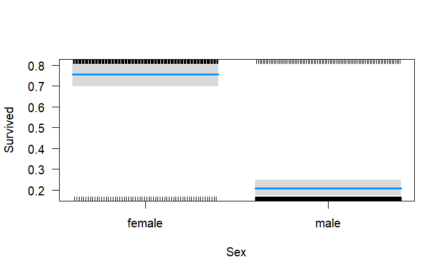

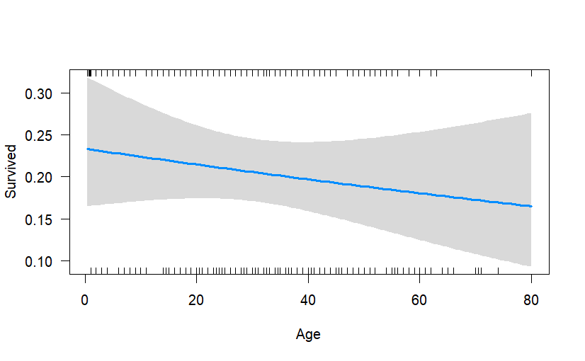

```r
visreg(reg_survived_sex_age, scale = "response")
```

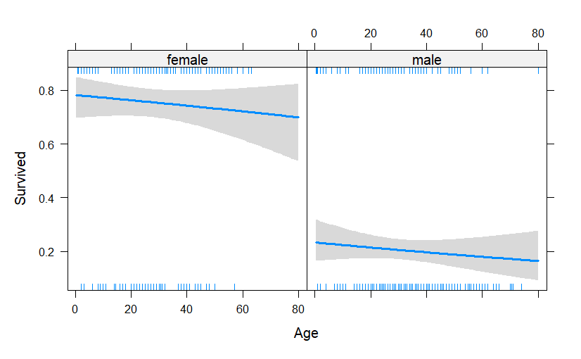

```r
visreg(reg_survived_sex_age, xvar = "Age", by = "Sex", scale = "response")
```

```stata
quietly logit Survived Sex Age
margins, at (Age = (0(0.2)50) Sex = (0(1)1))
marginsplot, noci plotopts(msize(0) lwidth(.6))
```

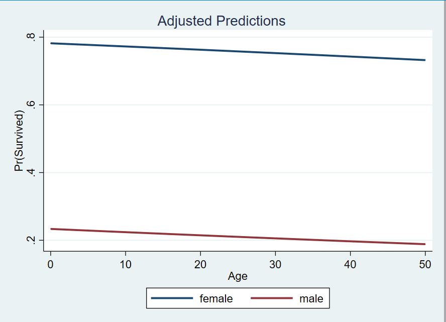

### Example: Adding a dummy interaction term

Now we expand the previous model, including an interactionterm between age and sex

```r
reg_survived_sex_int_age <- glm(Survived ~ Sex*Age,
                                data = titanic,
                                family = binomial(link = "logit"))
psummary(reg_survived_sex_int_age, accuracy = T)
```

```
 Model fit: Survived
# Color data frame (class colorDF) 1 x 5:
                  │Values
Number of Obs   = │ 714.000
Log Likelyhood  = │-370.202
Chi Square      = │ 224.113
Prob > ChiSq    = │   0.000
Pseudo R2       = │   0.232


 Coefficients: Survived
# Color data frame (class colorDF) 6 x 4:
           │Coefficients│std.error│t-value│p-value│CI[2.5%]│CI[97.5%]
(Intercept)│       0.594│    0.310│   1.91│0.05569│  -0.009│    1.212
    Sexmale│      -1.318│    0.408│  -3.23│0.00125│  -2.126│   -0.522
        Age│       0.020│    0.011│   1.86│0.06240│  -0.001│    0.041
Sexmale:Age│      -0.041│    0.014│  -3.03│0.00241│  -0.068│   -0.015


 Predicted and Observed Positives and Negatives
# Color data frame (class colorDF) 3 x 3:
                 │Predicted Negative│Predicted Positive│Total
Observed Negative│               360│                93│  453
Observed Positive│                64│               197│  261
            Total│               424│               290│  714


 Sensitivity and Specificity
# Color data frame (class colorDF) 1 x 4:
                         │Percentage
              Sensitivity│     0.679
              Specificity│     0.849
 Positve Predictive Value│     0.755
Negative Predictive Value│     0.795
```

```
Iteration 0:   log likelihood = -482.25798
Iteration 1:   log likelihood = -370.87822
Iteration 2:   log likelihood = -370.20307
Iteration 3:   log likelihood = -370.20172
Iteration 4:   log likelihood = -370.20172

Logistic regression                             Number of obs     =        714
                                                LR chi2(3)        =     224.11
                                                Prob > chi2       =     0.0000
Log likelihood = -370.20172                     Pseudo R2         =     0.2324

------------------------------------------------------------------------------
    Survived |      Coef.   Std. Err.      z    P>|z|     [95% Conf. Interval]
-------------+----------------------------------------------------------------
         Sex |
       male  |  -1.317751   .4084246    -3.23   0.001    -2.118249   -.5172535
         Age |    .019702   .0105729     1.86   0.062    -.0010205    .0404244
   Sex#c.Age |
       male  |  -.0411185   .0135511    -3.03   0.002     -.067678   -.0145589
       _cons |   .5938009   .3103246     1.91   0.056     -.014424    1.202026
------------------------------------------------------------------------------


Logistic model for Survived

              -------- True --------
Classified |         D            ~D  |      Total
-----------+--------------------------+-----------
     +     |       197            64  |        261
     -     |        93           360  |        453
-----------+--------------------------+-----------
   Total   |       290           424  |        714

Classified + if predicted Pr(D) >= .5
True D defined as Survived != 0
--------------------------------------------------
Sensitivity                     Pr( +| D)   67.93%
Specificity                     Pr( -|~D)   84.91%
Positive predictive value       Pr( D| +)   75.48%
Negative predictive value       Pr(~D| -)   79.47%
--------------------------------------------------
False + rate for true ~D        Pr( +|~D)   15.09%
False - rate for true D         Pr( -| D)   32.07%
False + rate for classified +   Pr(~D| +)   24.52%
False - rate for classified -   Pr( D| -)   20.53%
--------------------------------------------------
Correctly classified                        78.01%
--------------------------------------------------
```

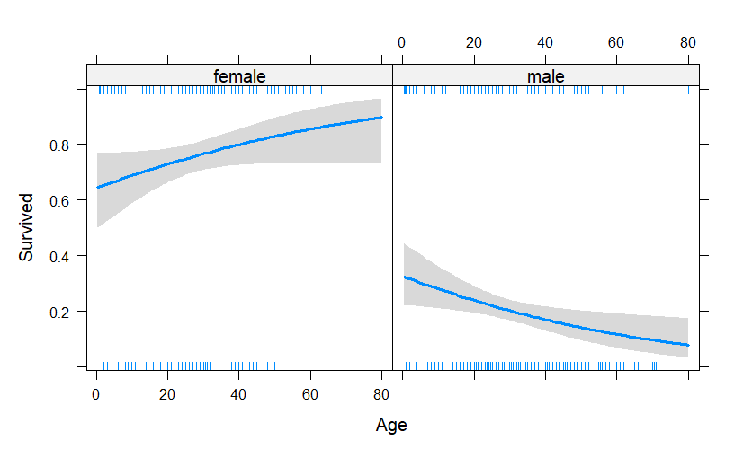

```r
visreg(reg_survived_sex_int_age, xvar = "Age", by = "Sex", scale = "response")
```

Since we have saturated all interaction terms, we can simply plot the effect for each sex seperately

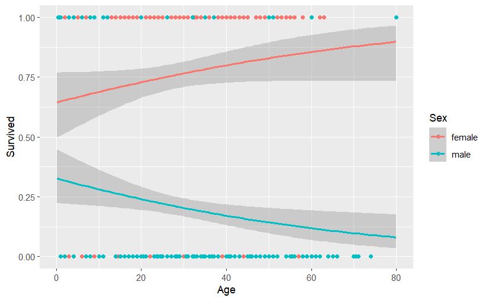

```r
titanic %>%  ggplot(aes(x = Age,
                        y = Survived,
                        colour = Sex)) +
  geom_point() +
  geom_smooth(method = "glm",
              method.args = list(family = binomial),
              fullrange = T)
```

```stata
quietly logit Survived i.Sex##c.Age
margins, at(Age = (0(0.5)50) Sex = (0(1)1))
marginsplot, noci plotopts(lwidth(0.6) msize(0))
```

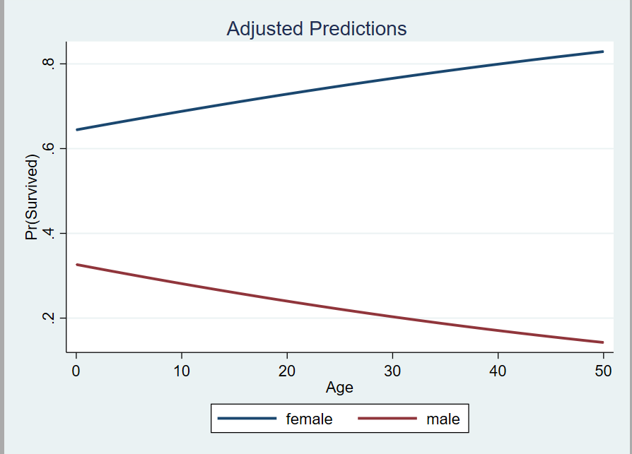

## Example: Adding a second covariate with interaction

1. In this example we expand our previous model to include a second ordinal variable *Pclass.*
2. We will saturate all interactionterms

```r
reg_int_sex_age_pclass <- glm(Survived ~ Sex*Age*Pclass,
                              data = titanic,
                              family = binomial(link = "logit"))

psummary(reg_int_sex_age_pclass, a = T)
```

```
 Model fit: Survived
# Color data frame (class colorDF) 1 x 5:
                  │Values
Number of Obs   = │ 714.000
Log Likelyhood  = │-310.426
Chi Square      = │ 343.663
Prob > ChiSq    = │   0.000
Pseudo R2       = │   0.356


 Coefficients: Survived
# Color data frame (class colorDF) 6 x 8:
                  │Coefficients│std.error│t-value│p-value│CI[2.5%]│CI[97.5%]
       (Intercept)│       5.590│    2.211│  2.529│ 0.0115│   1.576│   10.275
           Sexmale│      -3.994│    2.372│ -1.683│ 0.0923│  -8.951│    0.390
               Age│       0.027│    0.067│  0.410│ 0.6818│  -0.098│    0.164
            Pclass│      -1.680│    0.782│ -2.149│ 0.0316│  -3.312│   -0.238
       Sexmale:Age│      -0.055│    0.070│ -0.780│ 0.4355│  -0.198│    0.078
    Sexmale:Pclass│       0.971│    0.860│  1.129│ 0.2587│  -0.644│    2.738
        Age:Pclass│      -0.019│    0.024│ -0.775│ 0.4385│  -0.069│    0.027
Sexmale:Age:Pclass│       0.009│    0.027│  0.346│ 0.7297│  -0.041│    0.064


 Predicted and Observed Positives and Negatives
# Color data frame (class colorDF) 3 x 3:
                 │Predicted Negative│Predicted Positive│Total
Observed Negative│               389│               105│  494
Observed Positive│                35│               185│  220
            Total│               424│               290│  714


 Sensitivity and Specificity
# Color data frame (class colorDF) 1 x 4:
                         │Percentage
              Sensitivity│     0.638
              Specificity│     0.917
 Positve Predictive Value│     0.841
Negative Predictive Value│     0.787
```

```
Iteration 0:   log likelihood = -482.25798
Iteration 1:   log likelihood = -314.37809
Iteration 2:   log likelihood = -310.51599
Iteration 3:   log likelihood = -310.42673
Iteration 4:   log likelihood = -310.42649
Iteration 5:   log likelihood = -310.42649

Logistic regression                             Number of obs     =        714
                                                LR chi2(7)        =     343.66
                                                Prob > chi2       =     0.0000
Log likelihood = -310.42649                     Pseudo R2         =     0.3563

------------------------------------------------------------------------------
    Survived |      Coef.   Std. Err.      z    P>|z|     [95% Conf. Interval]
-------------+----------------------------------------------------------------
         Sex |
       male  |  -3.993732   2.372354    -1.68   0.092    -8.643462    .6559966
         Age |   .0273506   .0667169     0.41   0.682    -.1034121    .1581133
   Sex#c.Age |
       male  |  -.0549477   .0704581    -0.78   0.435    -.1930431    .0831476
      Pclass |    -1.6801   .7818327    -2.15   0.032    -3.212464    -.147736
Sex#c.Pclass |
       male  |   .9711787   .8599343     1.13   0.259    -.7142616    2.656619
       c.Age#|
    c.Pclass |  -.0189667   .0244795    -0.77   0.438    -.0669456    .0290122
   Sex#c.Age#|
    c.Pclass |
       male  |   .0092882   .0268806     0.35   0.730    -.0433968    .0619732
       _cons |    5.58967   2.210567     2.53   0.011     1.257038    9.922301
------------------------------------------------------------------------------
```

**R**

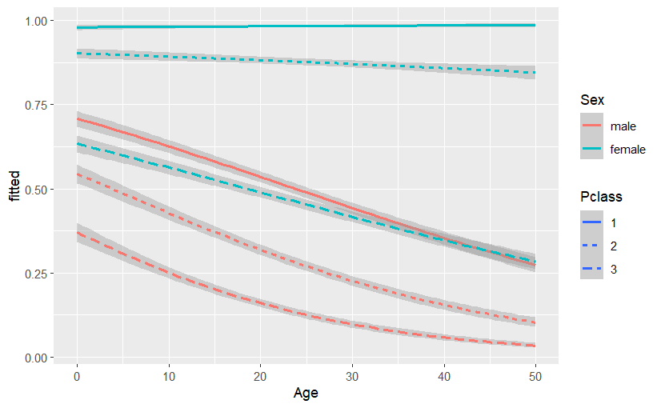

```r
library(margins)

predictions <- margins(reg_int_sex_age_pclass, at = list(Sex = c("male",
                                                                 "female"),
                                                         Pclass = c(1,2,3),
                                                         Age = seq(0,50,10)
                                          )
                       )
predictions <- predictions %>% mutate(Pclass = as.factor(Pclass))

predictions %>% ggplot(aes(x = Age,
                           y = fitted,
                           colour = Sex,
                           linetype = Pclass)
                       ) +
  geom_smooth(method = "glm", method.args = list(family = binomial))
```

**STATA**

```stata
quietly logit Survived i.Sex##c.Age##c.Pclass
margins, at (Age = (0(0.5)50) Sex = (0(1)1) Pclass = (1(1)3))
marginsplot, noci plotopts(msize(0) lwidth(0.6))
```

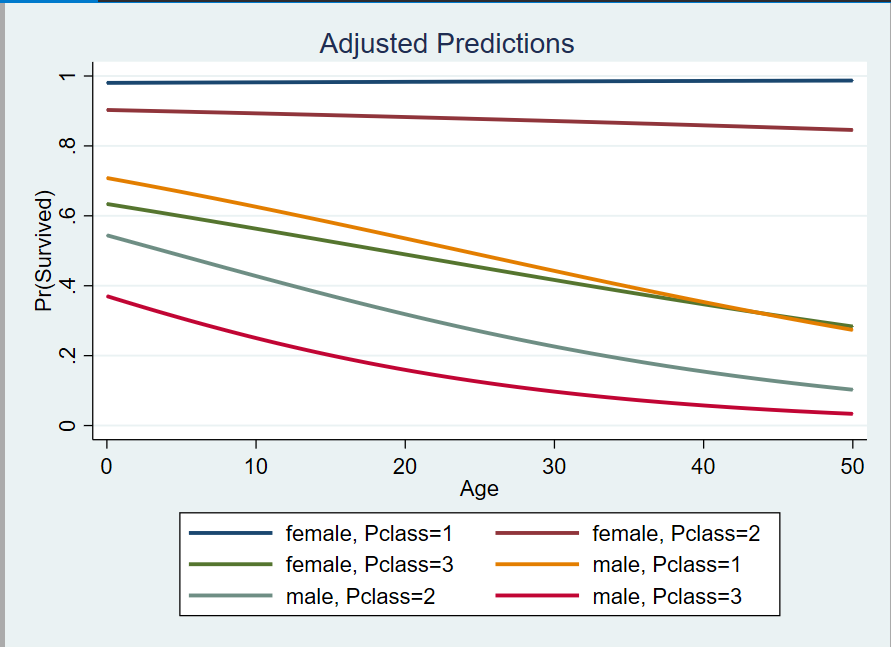

This is a quite messy, so we could instead create a seperate plot for each Pclass

**R**

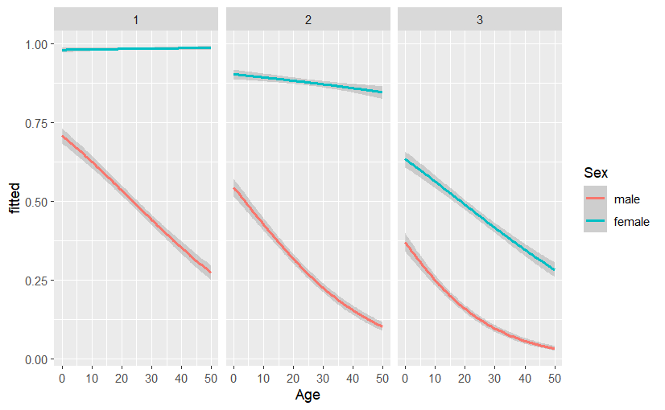

```r
predictions <- margins(reg_int_sex_age_pclass, at = list(Sex = c("male",
                                                                 "female"),
                                                         Pclass = c(1,2,3),
                                                         Age = seq(0,50,10)
                                          )
                       )
predictions <- predictions %>% mutate(Pclass = as.factor(Pclass))

predictions %>% ggplot(aes(x = Age,
                           y = fitted,
                           colour = Sex)
                       ) +
  geom_smooth(method = "glm", method.args = list(family = binomial)) +
  facet_wrap(~ Pclass)
```

**STATA**

I do not know a very elegant way of making stata make three distinct plots, since the marginsplot command does not take the *by :* prefix. But we can do it in three separate iterations

marginsplot, noci plotopts(msize(0))

```stata
// Pclass = 1
quietly logit Survived i.Sex##c.Age##c.Pclass
margins, at (Age = (0(0.5)50) Sex = (0(1)1) Pclass = 1)
marginsplot, noci plotopts(msize(0) lwidth(0.7))

// Pclass = 2
quietly logit Survived i.Sex##c.Age##c.Pclass
margins, at (Age = (0(0.5)50) Sex = (0(1)1) Pclass = 2)
marginsplot, noci plotopts(msize(0) lwidth(0.7))

// Pclass = 3
quietly logit Survived i.Sex##c.Age##c.Pclass
margins, at (Age = (0(0.5)50) Sex = (0(1)1) Pclass = 3)
marginsplot, noci plotopts(msize(0) lwidth(0.7))
```

**Pclass = 1**

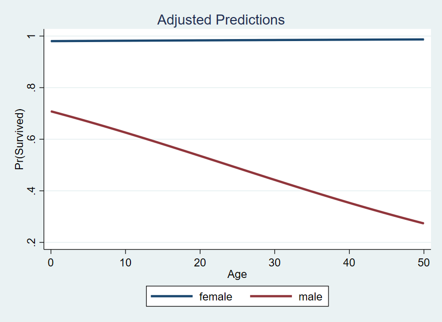

**Pclass = 2**

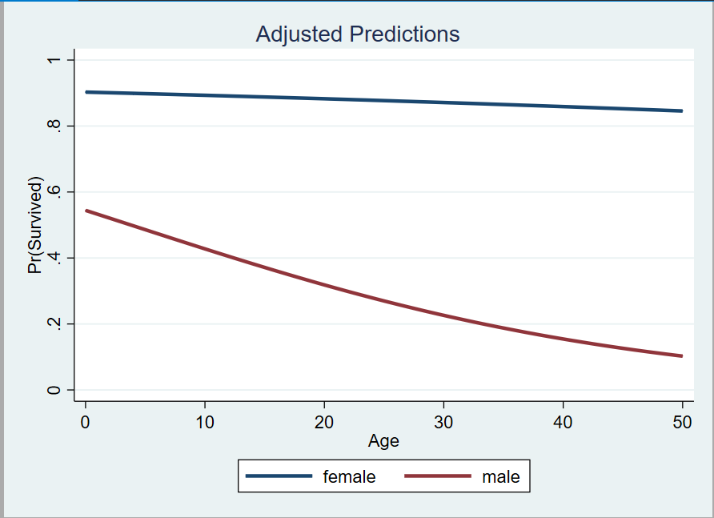

**Pclass = 3**

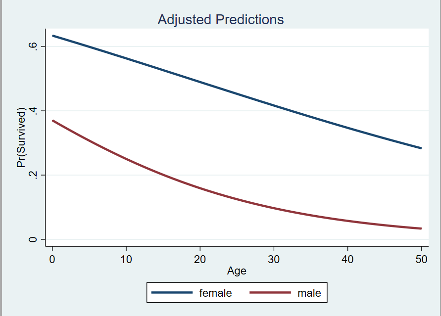

## Exercises

1. Run a multiple logistic regression with Survived as dependent variable, and inpendent variables as: Sex and Age2
2. Interpret the regression
3. Find the difference in probability of surviving between men and women at mean(Age2)
4. Visualize the model
5. Add an interactionterm to the model in exercise 1, and repeat exercises 2-4

# Appendix

## Appendix 1: Code used to generate Age2

```r
# Here i use the rnorm function (which draws a random number from a norm-dist.) to generate values from two different distributions for those who survived, and those who died, using the case_when function,
titanic2 <- titanic %>% mutate(Age2 = case_when(
                                 Survived == 0 ~ rnorm(Survived, 15, 3),
                                 Survived == 1 ~ rnorm(Survived, 27, 4)
                                 )
                               )

# Here i use the round function to remove decimals (i.e., making them integers)
titanic2 <- titanic2 %>% mutate(Age2 = round(Age2))
```

```r
interpretation_1 <- "1. Firstly we can see that the model as a whole is significant and has a large Pseudo R2 \n
2. Secondly we can see that the intercept is -24, indicating an estimated log(odds) (logit) of -24 at age = 0. \n
3. Thirdly we can see that the coefficient for age2 is 1.18 (p <.001) indicating a 1.18 increas in logit (increasing odds for surviving) per one unit change (1 year) in age. \n"

interpretation_2 <- "1. Firstly we can see that the model as a whole is significant and has a large Pseudo R2 \n
2. Secondly we can see that the intercept is 1.277-, indicating an estimated log(odds) (logit) of 1.277 at age = 0 and sex = female. \n
3. Thirdly we can see that the coefficient for age is -0.0054 (p = .390) which is not significant, if it were it would indicate a 0.0054 decrease in logit (decreasing odds for surviving) per one unit change (1 year) in age, controlled for sex. \n
4. We can se that Sex has a coefficient of -2.47 (p < .001) indicating that men have 2.47 lower log(odds) of surviving. \n
5. We can see that the model has an okay sensitivity at 67%, and a better specificity at 84.91%, but this is likely because more people died, than survived"
```